# 36-315 Lab Exam, Spring 2017

Solutions

Due: Wednesday, March 8th, 1:25pm

# Lab Exam: Movie Night

```r
#  Load packages
library(tidyverse)
library(forcats)
library(devtools)
library(ggforce)

#  Load in geom_mosaic() code if necessary
source_url("https://raw.githubusercontent.com/sventura/315-code-and-datasets/master/code/geom_mosaic.R")

#  Simple theme with white background, legend at the bottom
my_theme <-  theme_bw() +
  theme(axis.text = element_text(size = 12, color="indianred4"),
        text = element_text(size = 14, face="bold", color="darkslategrey"),
        legend.position="bottom")

#  Colorblind-friendly color pallette
my_colors <- c("#000000", "#56B4E9", "#E69F00", "#F0E442", "#009E73", "#0072B2",
               "#D55E00", "#CC7947")

#  Read in the data
imdb <- read_csv("https://raw.githubusercontent.com/sventura/315-code-and-datasets/master/data/imdb_test.csv")
```

# Problem 1

(40 points)

**All About Content**

Graph: 12 points

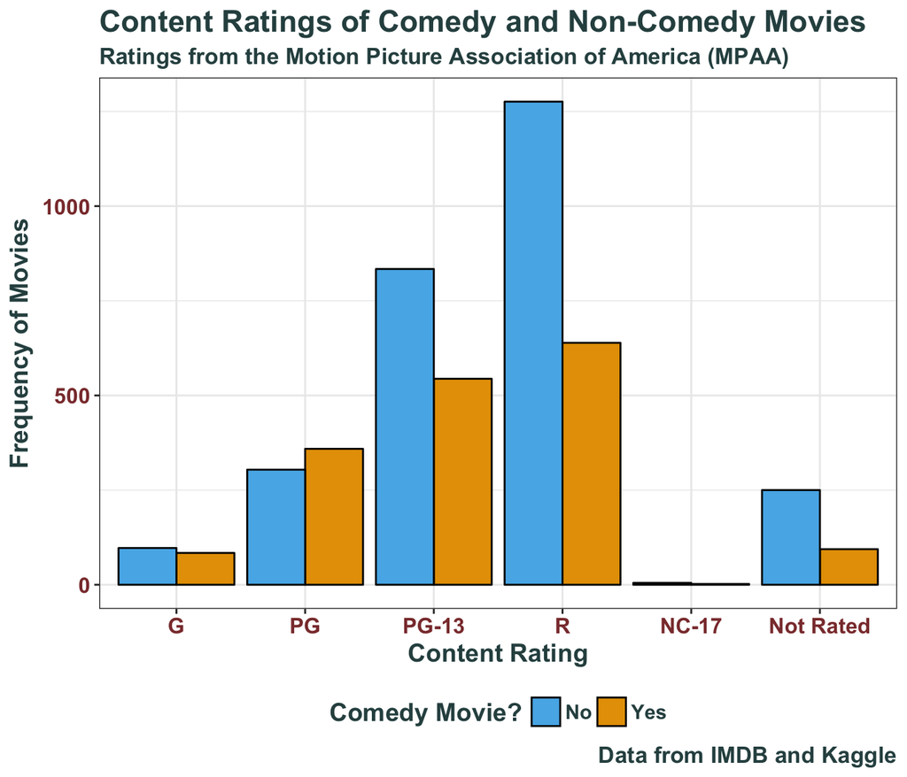

```r
rating_order <- c("G", "PG", "PG-13", "R", "NC-17", "Not Rated")
imdb <- mutate(imdb, is_comedy = ifelse(grepl(pattern = "Comedy", x = genres),
                                        "Yes", "No"),
               content_rating = fct_recode(content_rating,
                                           "Not Rated" = "N/A or Unrated",
                                           "G" = "Validated for All Ages (G)"),
               ordered_content = fct_relevel(content_rating, rating_order))

ggplot(data = imdb, aes(x = ordered_content, fill = is_comedy)) +
  geom_bar(position = "dodge", color = "black") +
  scale_fill_manual(values = my_colors[-1]) +
  labs(title = "Content Ratings of Comedy and Non-Comedy Movies",
       subtitle = "Ratings from the Motion Picture Association of America (MPAA)",
       caption = "Data from IMDB and Kaggle",
       x = "Content Rating",
       y = "Frequency of Movies",
       fill = "Comedy Movie?") +
  my_theme
```

1. (7 points) Characterize the distribution of the `content_rating` of IMDB movies. Describe any interesting features you see.

The content ratings of movies are assigned by the Motion Picture Association of America and are ordered from “G” (all ages admitted) to “NC-17” (no children under 17 admitted; formerly “X”). In our particular subset of movies from IMDB, there are very few G-rated movies, and the frequency of movies in each category increases as the movies are rated more strictly (more PG movies than G, more PG-13 than PG, and more R than PG-13), with R-rated movies having the most with 1915. There are very few NC-17 movies, and about 300-350 movies that were classified as “N/A or Not Rated”, shown as “Not Rated” in the graph.

2. (7 points) Compare the conditional distributions of whether or not a movie was a comedy given the `content_rating` of the movie. Describe any interesting features you see.

The conditional distributions of whether or not the movie is a comedy given each content rating can be found by comparing the heights of the bars within each content rating. Since PG is the only content rating for which the comedy bar is higher than the non-comedy bar, we know that they have the highest proportion of comedy movies (shown in orange-yellow). G movies also have a high proportion of comedies (nearly 50%), while other categories (PG-13, R, and Not Rated) have a much higher proportion of non-comedy movies.

3. (5 points) Which category of `content_rating` has the highest proportion of comedies? Provide visual or statistical evidence, and explain how the evidence leads you to your answer.

As discussed in (b), since PG is the only content rating for which the comedy bar is higher than the non-comedy bar, we know that they have the highest proportion of comedy movies (shown in orange-yellow).

4. (4 points) Is the `content_rating` of IMDB movies independent of whether or not the movie is a comedy? Provide visual or statistical evidence, and explain how the evidence leads you to your answer.

No, content rating is not independent of whether or not the movie is a comedy.

We cannot answer this question visually given our graphical choice, but we can answer this with a chi-square test:

```r
chi_sq <- chisq.test(table(imdb$ordered_content, imdb$is_comedy))
chi_sq
```

```
##
##  Pearson's Chi-squared test
##
## data:  table(imdb$ordered_content, imdb$is_comedy)
## X-squared = 113.75, df = 5, p-value < 2.2e-16
```

Chi-square tests assume that the two variables being tested are independent and return a test statistic an p-value indicating the likelihood of observing data at least as extreme as what we observed given this assumption.

In our case, the p-value is 0 (approximately zero), indicating that we have substantial evidence to reject the null hypothesis that content rating is independent of whether or not the movie is a comedy.

5. (5 points) Write 1-3 sentences describing why you made certain choices in your graphic.

A side-by-side bar chart allows us to have a good picture of the marginal distribution of content rating, while also allowing for an easy visualization of the conditional distributions of whether or not the movie is a comedy given the content rating. I chose the side-by-side bar chart because it easily allowed me to answer questions (a), (b), an (c), but if I were to repeat this problem, I might choose a mosaic plot, since it would allow me to answer all of parts (a)–(d). I reordered the categories into their logical and given order, and renamed the “G” category so that it no longer had a verbose and unnecessarily long name.

6. (BONUS: 3 points) Your friend tells you that 4% of all movies are rated G, 15% are PG, 30% are PG-13, 43% are R, 0.5% are NC-17, and 7.5% of are N/A or Unrated. Is there evidence to reject your friend’s claim? Provide visual or statistical evidence, and explain how this evidence leads you to your answer.

This claim can be checked with a simple chi-square test:

```r
imdb %>% group_by(ordered_content) %>%
  summarize(percentage = round(n() / nrow(imdb) * 100, 2))
```

```
## # A tibble: 6 × 2
##   ordered_content percentage
##            <fctr>      <dbl>
## 1               G       4.03
## 2              PG      14.77
## 3           PG-13      30.70
## 4               R      42.67
## 5           NC-17       0.16
## 6       Not Rated       7.66
```

```r
chisq.test(x = table(imdb$ordered_content),
           p = c(0.04, 0.15, 0.3, 0.43, 0.005, 0.075))
```

```
##
##  Chi-squared test for given probabilities
##
## data:  table(imdb$ordered_content)
## X-squared = 11.809, df = 5, p-value = 0.0375
```

Even though my friend’s given proportions may seem approximately correct, the chi-square test shows that we have enough evidence to reject the null hypothesis that my friend’s given percentages are correct and conclude that the true distribution is different from what he claims.

### Sam Says:

- It’s important to order the categories in an appropriate order here
- It’s important to give the categories a consistent naming system (i.e. changing “Validated for all ages (G)” to “G” to match the other categories)
- It’s important to discuss the order of the categories in your response, especially in part (a).
- Definitely do not remove the “N/A or Not Rated” movies – never remove data unnecessarily
- It would be fine to show the “N/A or Not Rated” movies on the left-hand side as well
- In (c), if you used a stacked bar chart, it might be difficult to give a definitive answer to this question using only your graph. In this case, you should compute the proportions, e.g. as is done below:

```r
imdb %>% group_by(ordered_content) %>%
  summarize(total = n(),
            comedy = round(sum(is_comedy == "Yes") / total, 2),
            non_comedy = round(sum(is_comedy == "No") / total, 2))
```

```
## # A tibble: 6 × 4
##   ordered_content total comedy non_comedy
##            <fctr> <int>  <dbl>      <dbl>
## 1               G   181   0.46       0.54
## 2              PG   663   0.54       0.46
## 3           PG-13  1378   0.39       0.61
## 4               R  1915   0.33       0.67
## 5           NC-17     7   0.29       0.71
## 6       Not Rated   344   0.27       0.73
```

- In both (b) and (c), a mosaic plot would allow you to easily compare the conditional distributions of whether or not the movie is a comedy given its content rating.
- In (d), if you had used a mosaic plot, you could very easily answer the question about independence by looking at the colors of the boxes.

# Problem 6

(35 points)

**Time To Profit**

Graph: 12 points

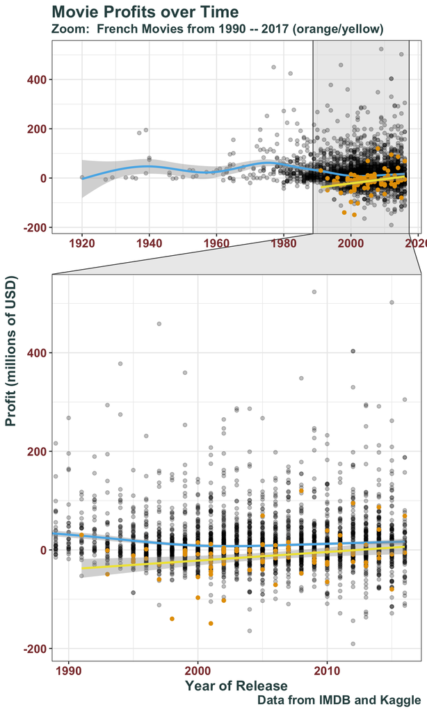

```r
imdb <- mutate(imdb, profit = (gross - budget) / 1000000,
               is_french = ifelse(country == "France", "Yes", "No")) %>%
  filter(movie_title != "The Messenger: The Story of Joan of Arc")
france_1990 <- filter(imdb, country == "France", title_year >= 1990)


ggplot(data = imdb, aes(x = title_year, y = profit)) +
  geom_point(color = my_colors[1], alpha = 0.25) +
  geom_smooth(color = my_colors[2]) +
  geom_point(data = france_1990, color = my_colors[3]) +
  geom_smooth(data = france_1990, aes(x = title_year, y = profit),
              color = my_colors[4], method = lm) +
  facet_zoom(x = title_year >= 1990) +
  labs(title = "Movie Profits over Time",
       subtitle = "Zoom:  French Movies from 1990 -- 2017 (orange/yellow)",
       caption = "Data from IMDB and Kaggle",
       x = "Year of Release",
       y = "Profit (millions of USD)") +
  my_theme
```

1. (6 points) Are movie profits increasing over time? Provide visual or statistical evidence, and explain how this evidence leads you to your answer.

It’s difficult to say anything definitive about the general trend of movie profits over time, since the average profit of movies both increases and decreases in different spans of years covered in our dataset. We should also not that if the given profits are not inflation-adjusted, then it is difficult to compare profits across different time spans. Nonetheless, between 1920 and 1975, there simply aren’t enough movies in the dataset to make a strong arguement about whether or not movie profits are increasing or decreasing. From 1975 to about 2000, movie profits seem to be decreasing, as shown by the blue non-linear trend line in the graph above. From 2000 to 2016, there appears to be a slight (but perhaps not statistically significant) uptick in movie profits, again evidenced by the blue non-lienr trend line in our graph. We zoom in on the portion of the graph from 1990 to 2016 to get a better visual of this. In any case, I would not say that movie profits are increasing over all spans of time covered in our dataset.

2. (8 points) A popular movie critic claims that French films have experienced an increase in profits from 1990 to 2017. Do you agree? Provide visual or statistical evidence, and explain how this evidence leads you to your answer.

I agree with the critic, though the degree of this increase is very mild, especially after making some adjustments to errors in the data. First, note that there is one potential outlying negative-profit movie, called “The Messenger: The Story of Joan of Arc”. Comparing the gross and budget data in our dataset to what is listed publicly on IMDB.com, we see that these numbers are incorrect. After removing this observation from our dataset, we take the subset of all remaining French movies with title years from 1990 to 2016 and plot them in yellow-orange, adding a yellow linear trend line to this portion of the data only. In looking at the resulting graph, we see a clear increasing trend in the profits of French movies from 1990 to 2016, evidenced by the positive slope on the yellow regression line. As such, we conclude that the movie critic is correct in his analysis.

3. (2 points each) Examining correlations:
- What is the correlation between the `title_year` of the movie and its `profit`?
- How would you characterize this correlation (e.g. strong positive correlation, weak positive correlation, no correlation, weak negative correlation, or strong negative correlation)? Why? Explain.

4. (5 points) Write 1-3 sentences describing why you made certain choices in your graphic.

When creating the profit variable, we scale it to be in millions of US dollars to make the graph easier to read and interpret for the viewer. After first trying a linear trend line for the regression for all movies, we use a non-linear trend line to show that the relationship between title year and profit is not constant over time. We color the post-1990 French movies in yellow-orange, then use a similar yellow linear regression line to show their trend over time.

Note: You haven’t learned about `facet_zoom()` yet, but we use it here to show how zooming in on a particular region of the graphic can help to improve our understanding of particular features of the graph and relationships between the variables.

### Sam Says:

- It is not appropriate to include a large amount of unnecessary information in your graph (e.g. trend lines for each country, colors for each country, one facet for each country, etc).
- If you used facetting, the only way this would be appropriate is if you created an `is_french` variable and facetted on that, including the “(all)” facet as well. Including one facet for every country gives way too much information and only serves to confuse the viewer.
- If you used a trend line to analyze the French movies in part (b), you should have either fit the trend line to French movies after 1990 or used a non-linear trend line. If you included French movies before 1990 in your regression analysis, these influenced the regression, so that your regression results did not necessarily answer the question. If, on the other hand, you used a non-linear trend line, this would have been okay, since this shows the local trends and would ignore movies well before 1990 when being fit to French movies after 1990.
- In part (c), you should remove the NA observations when computing the correlation.
- In your graph, ALWAYS include units where appropriate!

# Problem 7

**Multiple Choice Questions**

(5 points each; 25 points total)

Answer the questions at [this link](https://goo.gl/forms/91b6oS9dpi2svBfM2).

1. Problem 7a: When might it be appropriate to use a log transformation when visualizing a continuous variable? I.e., for a variable called X, to visualize log(X) instead?

2. Problem 7b: Which of the following statements about boxplots are FALSE? (Check all that apply.)

TRUE: The definition of outliers in boxplots is somewhat arbitrary

TRUE: Boxplots distort the visual perception of the distribution

FALSE: We can determine the modality of the distribution with a boxplot

TRUE: We can determine if the distribution is skewed with a boxplot

FALSE: Sam thinks boxplots are the best way to display any continuous distribution

3. Problem 7c: Which of the following factors might you consider when choosing the bin width for a histogram of a single continuous variable? (Check all that apply.)

The number of rows in the dataset (sample size)

The range of the variable (difference of maximum and minimum values)

The standard deviation of the variable

4. Problem 7d: What information can you determine from a mosaic plot? (Check all that apply.)

Marginal Distribution of Variable 1 (at the proportion scale)

Conditional Distribution of Variable 2 given Variable 1 (at the proportion scale)

Whether or not Variable 1 and Variable 2 are independent

5. Problem 7e: When visualizing a variable’s distribution, what conditions are necessary in order to assert that the variable is normally distributed? (Check all that apply.)

The distribution is symmetric

The distribution is unimodal

The distribution is bell-shaped